# STAT40710 Time Series Project Diff Phi AR1

Fangyijie Wang

7/2/2022

Load required libraries.

```r
library(TSA)
library(fGarch)
library(forecast)
library(tseries)
library(reshape2)
library(ggplot2)
```

Create required functions.  
* Calculate ACF and PACF

```r
acf_identifier <- function(x, lags){
  # ACF
  ro <- acf(x, lag.max = lags, plot = FALSE)
  # PACF
  phi <- pacf(x, lag.max = lags, plot = FALSE)

  return(cbind(acf = ro$acf, pacf = phi$acf))
}
```

- Identify orders

```r
order_identifier <- function(acf_pacf, lags){
  p_hat <- 1
  q_hat <- 1

  for(l in (2:lags)){
    if(abs(acf_pacf[,'acf'][l]) > ci[2]){
      q_hat = q_hat + 1
    }
    else{
      break
    }
  }

  for(l in (2:lags)){
    if(abs(acf_pacf[,'pacf'][l]) > ci[2]){
      p_hat = p_hat + 1
    }
    else{
      break
    }
  }
  return(list(p_hat = p_hat, q_hat = q_hat))
}
```

- Simulate Multiple Series AR(1) with Shared GARCH(1,1)

```r
sim_series <- function(u, K, n, lags, ci, eta){
  multi_series = matrix(NA, K, n)
  series_param = matrix(NA, nrow = K, ncol = 4)
  # multiple time series share the same eta_t part
  for(k in 1:K){
    # generate different phi each time
    # phi needs to be close to 1.0
    phi = runif(1, min = 0.7, max = 0.9)

    skip_to_next <- FALSE

    series_param[k,1] = u

    # the values of AR coefficients (ARIMA)
    series_param[k,2] = phi

    possibleError <- tryCatch({
      # use shared eta to simulate a AR(u) model
      multi_series[k,] = arima.sim(list(ar = phi), n, innov = eta$garch)

      # ACF
      series_ro <- pacf(multi_series[k,], lag.max = lags, plot = FALSE)
      series_param[k,3] <- sum(abs(series_ro$acf) > ci[2])
      series_param[k,4] <- 1
      },
      error = function(e) {
        e
        print(paste("Skip the non-stationary series in loop ",k,sep = ""))
        })

    if(inherits(possibleError, "error")) next
  }
  results <- list(series = multi_series, params = series_param)
  return(results)
}
```

Firstly, we need to initialize hyperparameters:

```r
u = 1 # AR order
v = 0 # MA order
p = 1 # GARCH order
q = 1 # GARCH order
```

Setup fixed values of parameters.

```r
mu = 0 # (the linear part) the mean value, by default NULL
omega = 0.01 # the constant coefficient of the variance equation (default 1e-6)
alpha = 0.2
beta = 0.5
lags = 20

# length of time series
n = 300
```

### Simulate Multiple Time Series AR(1)+GARCH(1,1)

- Fixed order $u$

```r
# n = 300
K = 100  # simulate 100 time series
acf_matrix <- matrix(NA, ncol = 2, nrow = lags, dimnames = list(NULL,c('acf','pacf')))
# confidence interval
ci = c(-1.96/sqrt(n), 1.96/sqrt(n))
```

```r
# GARCH(1,1)
spec = garchSpec(model = list(mu = mu, omega = omega, alpha = alpha, beta = beta), cond.dist = "norm")
eta = garchSim(spec, n)
fitted.true <- garchFit(~ garch(1,1),
                        data=eta,
                        cond.dist="norm",
                        include.mean = FALSE,
                        trace = FALSE)
```

```r
res <- sim_series(u, K, n, lags, ci, eta)
multi_series <- res$series
series_param <- res$params
colnames(series_param) <- c("u", "phi1", "autocorrelation", "accepted")
```

```r
# check simulated series data
multi_series[1:5, 1:5]
```

```
##             [,1]        [,2]        [,3]        [,4]        [,5]
## [1,] -0.24979416 -0.27309407 -0.13151054 -0.07475251 -0.24516739
## [2,] -0.17188222 -0.20787504 -0.07805045 -0.02929504 -0.20585777
## [3,]  2.62065075  2.28862280  2.15378918  1.96595448  1.57788603
## [4,]  0.07014363 -0.00432132  0.10469277  0.11496597 -0.09786913
## [5,]  0.58912955  0.36818438  0.37176154  0.30703256  0.04047604
```

```r
# check series parameters
series_param[1:5,]
```

```
##      u      phi1 autocorrelation accepted
## [1,] 1 0.8761746               2        1
## [2,] 1 0.8938927               2        1
## [3,] 1 0.8939969               1        1
## [4,] 1 0.7115323               3        1
## [5,] 1 0.7170158               2        1
```

### Identify Multiple Models AR(1)+GARCH(1,1)

Identify $u$ for each series separately.

```r
target_series <- multi_series
N <- nrow(target_series)
lags <- 15
acf_matrix <- matrix(NA, ncol = 2, nrow = lags, dimnames = list(NULL,c('acf','pacf')))
estimate_orders <- matrix(NA, ncol = 2, nrow = N, dimnames = list(NULL,c('p_hat','q_hat')))
residuals_matrix <- matrix(NA, ncol = n, nrow = N)

for(index in (1:N)){
  tar_ts <- target_series[index,]

  # ACF
  ro <- acf(tar_ts, lag.max = lags, plot = FALSE)
  # PACF
  phi <- pacf(tar_ts, lag.max = lags, plot = FALSE)

  acf_matrix[,'acf'] <- as.vector(ro$acf)
  acf_matrix[,'pacf'] <- as.vector(phi$acf)
  arma_orders <- order_identifier(acf_matrix, lags)
  estimate_orders[index,] <- c(arma_orders$p_hat, arma_orders$q_hat)

  # assumption: series has AR component
  fit_ts = arima(tar_ts, order = c(arma_orders$p_hat,0,0), method = "ML")
  x = residuals(fit_ts)
  residuals_matrix[index,] <- x
}
```

Compare actual AR orders and estimated AR orders:

```r
# actual orders
series_param[,1]
```

```
##   [1] 1 1 1 1 1 1 1 1 1 1 1 1 1 1 1 1 1 1 1 1 1 1 1 1 1 1 1 1 1 1 1 1 1 1 1 1 1
##  [38] 1 1 1 1 1 1 1 1 1 1 1 1 1 1 1 1 1 1 1 1 1 1 1 1 1 1 1 1 1 1 1 1 1 1 1 1 1
##  [75] 1 1 1 1 1 1 1 1 1 1 1 1 1 1 1 1 1 1 1 1 1 1 1 1 1 1
```

```r
# estiamted orders
estimate_orders[,1]
```

```
##   [1] 1 1 1 1 1 1 1 1 1 1 1 1 1 1 1 1 1 1 1 1 1 1 1 1 1 1 1 1 1 1 1 1 1 1 1 1 1
##  [38] 1 1 1 1 1 1 1 1 1 1 1 1 1 1 1 1 1 1 1 1 1 1 1 1 1 1 1 1 1 1 1 1 1 1 1 1 1
##  [75] 1 1 1 1 1 1 1 1 1 1 1 1 1 1 1 1 1 1 1 1 1 1 1 1 1 1
```

### Estimate Shared GARCH Components

Calculate average of shared GARCH components.

```r
eta_hat <- colMeans(residuals_matrix)
```

Estimate GARCH orders

```r
x <- eta_hat
# ACF and PACF
arch_identify <- acf_identifier(x, lags)
garch_orders_hat <- order_identifier(arch_identify, lags)
garch_orders_hat$p_hat
```

```
## [1] 1
```

```r
garch_orders_hat$q_hat
```

```
## [1] 1
```

Fit $GARCH(1,1)$

```r
fit_res_square <- garchFit(~ garch(1,1),
                           data=x,
                           cond.dist="norm",
                           include.mean = FALSE,
                           trace = FALSE)
llh <- -unname(fit_res_square@fit$llh)
AIC <- (-2*(llh))/n + 2*(length(fit_res_square@fit$par))/n
AIC
```

```
## [1] -0.522046
```

### Check Residuals of GARCH (epsilon_t)

Look at Q-Q Plot of residuals of GARCH model, which is $\epsilon_t = \eta_t/sqrt(garchFit)$ = Residuals/sqrt(Conditional variance). We can compute it directly from R, and plot the Q-Q graph to check the normality of the residuals.

```r
garch_res = eta_hat / fit_res_square@sigma.t
```

Followings are the codes and Q-Q plot.

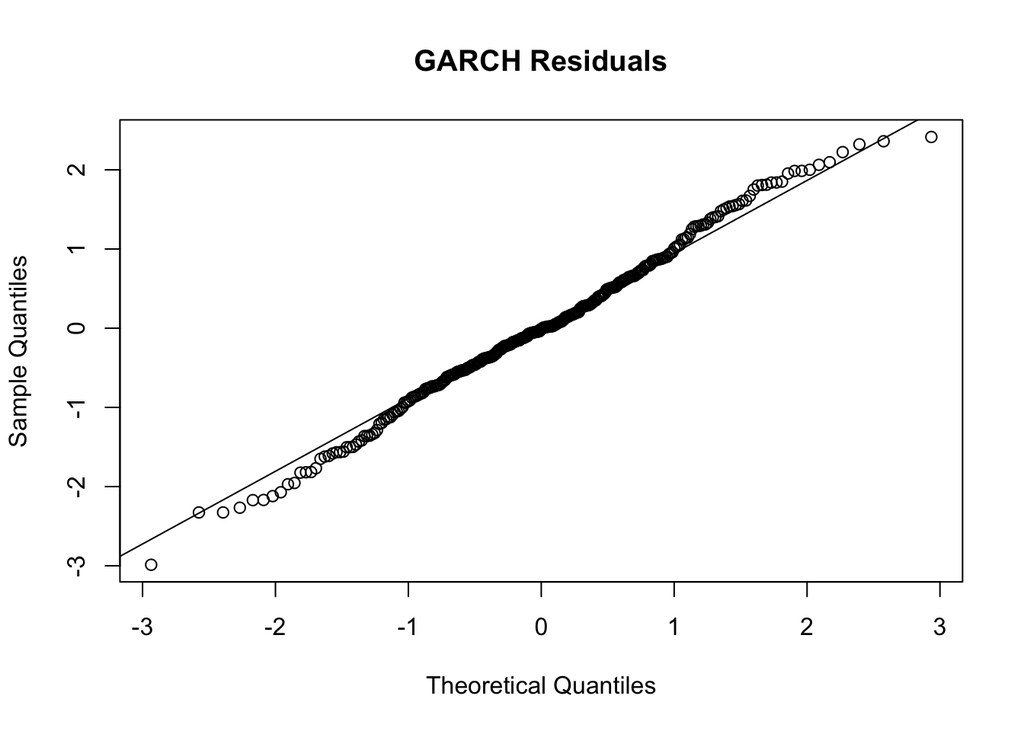

```r
garch_res <- as.matrix(garch_res)
qqnorm(garch_res, main='GARCH Residuals')
qqline(garch_res)
```

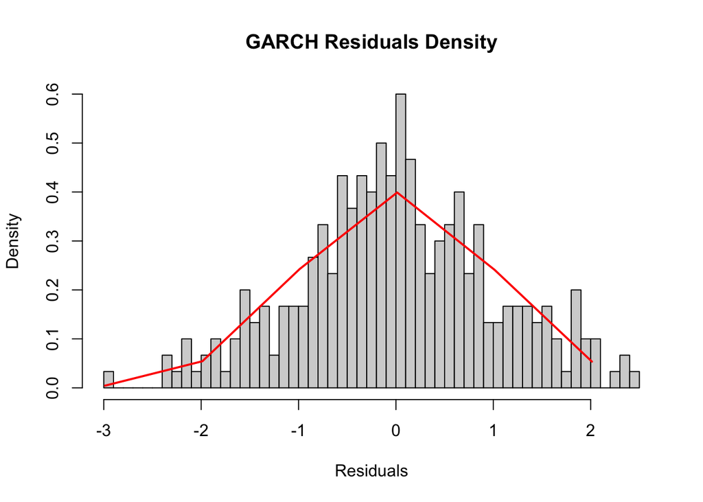

```r
# Density
hist(garch_res, prob = TRUE, breaks = 60, main = "GARCH Residuals Density", xlab="Residuals")
xlab <- seq(min(garch_res), max(garch_res))
ylab <- dnorm(xlab, mean = mean(garch_res), sd = sd(garch_res))
lines(xlab, ylab, col = "red", lwd = 2)
```

### How well Sigma_t of GARCH is estimated

Plot true $\eta^2$ vs $\sigma^2$

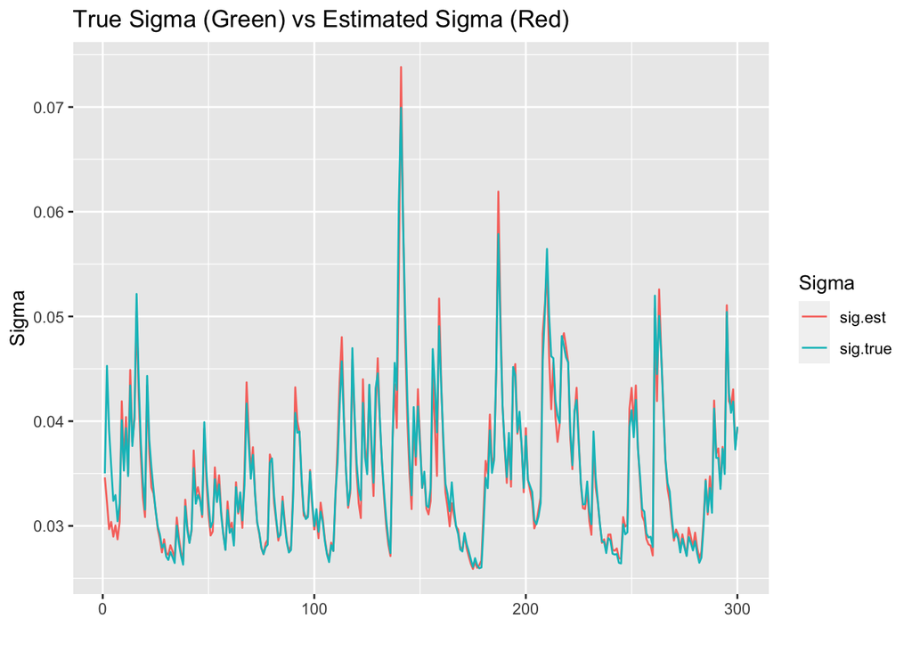

```r
sig.true <- fitted.true@h.t   #- this is true sigma
sig.est <- fit_res_square@h.t    #- estimated sigma

sig.comparison <- melt(cbind(sig.est, sig.true))
sig.comparison$Var2 <- as.factor(sig.comparison$Var2)

ggplot(data=sig.comparison, aes(x=Var1, y=value, colour=Var2)) +
  labs(title = "True Sigma (Green) vs Estimated Sigma (Red)") +
  xlab("") +
  ylab("Sigma") +
  labs(color="Sigma") +
  #geom_hline(yintercept = mean(sig.true), color = "#f4766d") +
  geom_line()
```

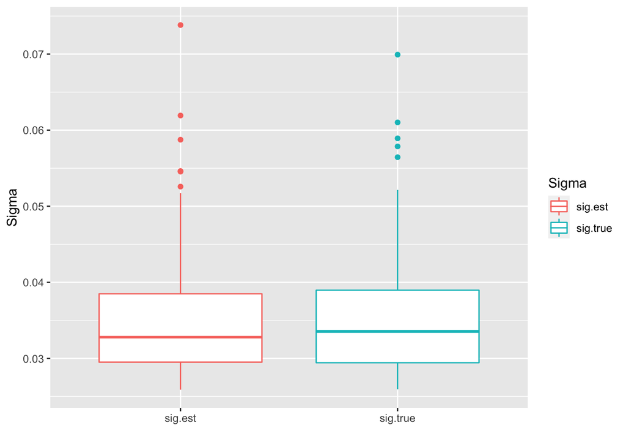

```r
ggplot(sig.comparison, aes(x=Var2, y=value, colour=Var2)) +
  xlab("") +
  ylab("Sigma") +
  labs(color="Sigma") +
  geom_boxplot()
```

### How well phi is estimated

```r
phi.est <- matrix(NA, nrow = nrow(target_series), ncol = 2)
phi.est[,1] <- estimate_orders[,1]
# focus on the selected simulation data
# remove shared GARCH from each series
estimated_ar <- target_series - eta_hat

for(j in (1:nrow(estimated_ar))){
  ar_fit <- arima(estimated_ar[j,],
                  order = c(estimate_orders[j,1],0,0),
                  method = "ML")
  # extract the estimated coefficients
  est_coef <- ar_fit$coef[1:estimate_orders[j,1]]
  phi.est[j,2:(length(est_coef)+1)] <- est_coef
}
colnames(phi.est) <- c("est_orders","est_phi_1")
```

```r
phi.true <- series_param[,1:2]
colnames(phi.true) <- c("true_orders","true_phi_1")
```

Phi MSE:

```r
# compute Mean Squared Error
phi.mse <- (1/K)*sum((phi.true[,2] - phi.est[,2])^2)
phi.mse
```

```
## [1] 0.03460226
```

[figure not shown]

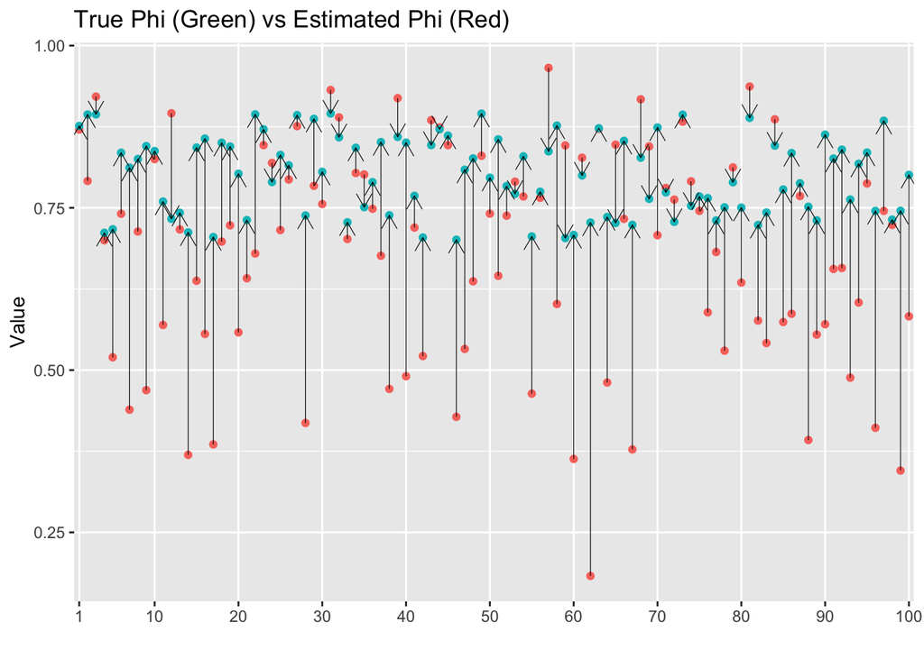

```r
phi.comparison$Var1 <- as.factor(phi.comparison$Var1)
ggplot(data=phi.comparison, aes(x=Var1, y=value), position=position_dodge(0.5)) +
  labs(title = "True Phi (Green) vs Estimated Phi (Red)") +
  xlab("") +
  ylab("Value") +
  labs(color="Phi") +
  geom_point(aes(colour=Var2)) +
  geom_line(arrow = arrow(length=unit(0.30, "cm")), size = 0.2) +
  scale_x_discrete(breaks = c("1","10","20","30","40","50","60","70","80","90","100")) +
  theme(legend.position="none")
```

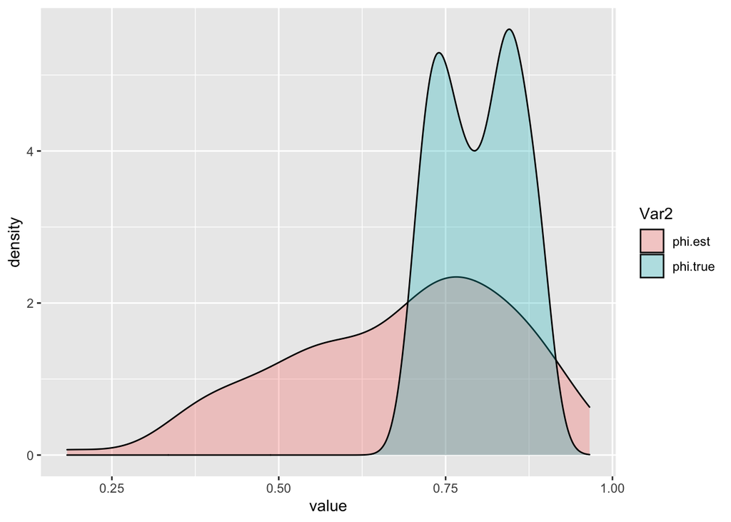

```r
# Density
ggplot(data = phi.comparison, aes(x=value, group=Var2, fill=Var2)) +
  geom_density(alpha=0.3)
```

### Increase Number of Series to 400

```r
K = 400  # simulate 400 time series
acf_matrix <- matrix(NA, ncol = 2, nrow = lags, dimnames = list(NULL,c('acf','pacf')))
# confidence interval
ci = c(-1.96/sqrt(n), 1.96/sqrt(n))
```

```r
res <- sim_series(u, K, n, lags, ci, eta)
multi_series <- res$series
series_param <- res$params
colnames(series_param) <- c("u", "phi1", "autocorrelation", "accepted")
```

Identify $u$ for each series separately.

```r
target_series <- multi_series
N <- nrow(target_series)
lags <- 15
acf_matrix <- matrix(NA, ncol = 2, nrow = lags, dimnames = list(NULL,c('acf','pacf')))
estimate_orders <- matrix(NA, ncol = 2, nrow = N, dimnames = list(NULL,c('p_hat','q_hat')))
residuals_matrix <- matrix(NA, ncol = n, nrow = N)

for(index in (1:N)){
  tar_ts <- target_series[index,]

  # ACF
  ro <- acf(tar_ts, lag.max = lags, plot = FALSE)
  # PACF
  phi <- pacf(tar_ts, lag.max = lags, plot = FALSE)

  acf_matrix[,'acf'] <- as.vector(ro$acf)
  acf_matrix[,'pacf'] <- as.vector(phi$acf)
  arma_orders <- order_identifier(acf_matrix, lags)
  estimate_orders[index,] <- c(arma_orders$p_hat, arma_orders$q_hat)

  # assumption: series has AR component
  fit_ts = arima(tar_ts, order = c(arma_orders$p_hat,0,0))
  x = residuals(fit_ts)
  residuals_matrix[index,] <- x
}
```

```r
# estiamted orders
estimate_orders[,1]
```

```
##   [1] 1 1 1 1 1 1 1 1 1 1 1 1 1 1 1 1 1 1 1 1 1 1 1 1 1 1 1 1 1 1 1 1 1 1 1 1 1
##  [38] 1 1 1 1 1 1 1 1 1 1 1 1 1 1 1 1 1 1 1 1 1 1 1 1 1 1 1 1 1 1 1 1 1 1 1 1 1
##  [75] 1 1 1 1 1 1 1 1 1 1 1 1 1 1 1 1 1 1 1 1 1 1 1 1 1 1 1 1 1 1 1 1 1 1 1 1 1
## [112] 1 1 1 1 1 1 1 1 1 1 1 1 1 1 1 1 1 1 1 1 1 1 1 1 1 1 1 1 1 1 1 1 1 1 1 1 1
## [149] 1 1 1 1 1 1 1 1 1 1 1 1 1 1 1 1 1 1 1 1 1 1 1 1 1 1 1 1 1 1 1 1 1 1 1 1 1
## [186] 1 1 1 1 1 1 1 1 1 1 1 1 1 1 1 1 1 1 1 1 1 1 1 1 1 1 1 1 1 1 1 1 1 1 1 1 1
## [223] 1 1 1 1 1 1 1 1 1 1 1 1 1 1 1 1 1 1 1 1 1 1 1 1 1 1 1 1 1 1 1 1 1 1 1 1 1
## [260] 1 1 1 1 1 1 1 1 1 1 1 1 1 1 1 1 1 1 1 1 1 1 1 1 1 1 1 1 1 1 1 1 1 1 1 1 1
## [297] 1 1 1 1 1 1 1 1 1 1 1 1 1 1 1 1 1 1 1 1 1 1 1 1 1 1 1 1 1 1 1 1 1 1 1 1 1
## [334] 1 1 1 1 1 1 1 1 1 1 1 1 1 1 1 1 1 1 1 1 1 1 1 1 1 1 1 1 1 1 1 1 1 1 1 1 1
## [371] 1 1 1 1 1 1 1 1 1 1 1 1 1 1 1 1 1 1 1 1 1 1 1 1 1 1 1 1 1 1
```

Estimate Shared GARCH Components. Calculate average of shared GARCH components.

```r
eta_hat <- colMeans(residuals_matrix)
```

Estimate GARCH orders

```r
x <- eta_hat
# ACF and PACF
arch_identify <- acf_identifier(x, lags)
garch_orders_hat <- order_identifier(arch_identify, lags)
garch_orders_hat$p_hat
```

```
## [1] 1
```

```r
garch_orders_hat$q_hat
```

```
## [1] 1
```

Fit $GARCH(1,1)$

```r
fit_res_square <- garchFit(~ garch(1,1),
                           data=x,
                           cond.dist="norm",
                           include.mean = FALSE,
                           trace = FALSE)
llh <- -unname(fit_res_square@fit$llh)
AIC <- (-2*(llh))/n + 2*(length(fit_res_square@fit$par))/n
AIC
```

```
## [1] -0.5215241
```

Check Residuals of GARCH.

```r
garch_res <- eta_hat / fit_res_square@sigma.t
```

Followings are the codes and Q-Q plot.

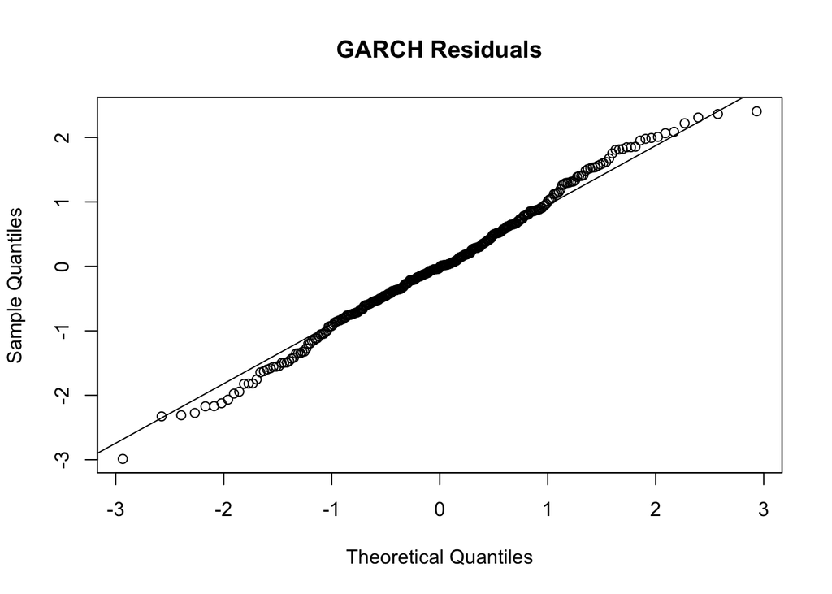

```r
garch_res <- as.matrix(garch_res)
qqnorm(garch_res, main='GARCH Residuals')
qqline(garch_res)
```

How well Sigma_t of GARCH is estimated ?  
Plot true $\eta^2$ vs $\sigma^2$

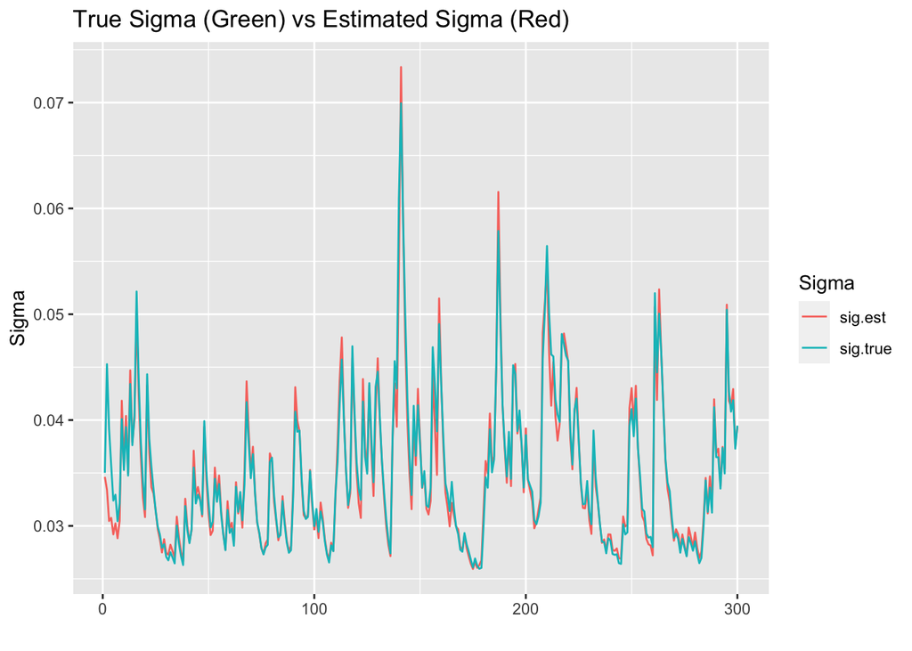

```r
sig.true <- fitted.true@h.t     #- this is true sigma
sig.est <- fit_res_square@h.t    #- estimated sigma

sig.comparison <- melt(cbind(sig.est, sig.true))
sig.comparison$Var2 <- as.factor(sig.comparison$Var2)

ggplot(data=sig.comparison, aes(x=Var1, y=value, colour=Var2)) +
  labs(title = "True Sigma (Green) vs Estimated Sigma (Red)") +
  xlab("") +
  ylab("Sigma") +
  labs(color="Sigma") +
  #geom_hline(yintercept = mean(sig.true), color = "#f4766d") +
  geom_line()
```

How well phi is estimated ?

```r
phi.est <- matrix(NA, nrow = nrow(target_series), ncol = 2)
phi.est[,1] <- estimate_orders[,1]
# focus on the selected simulation data
# remove shared GARCH from each series
estimated_ar <- target_series - eta_hat

for(j in (1:nrow(estimated_ar))){
  ar_fit <- arima(estimated_ar[j,],
                  order = c(estimate_orders[j,1],0,0),
                  method = "ML")
  # extract the estimated coefficients
  est_coef <- ar_fit$coef[1:estimate_orders[j,1]]
  phi.est[j,2:(length(est_coef)+1)] <- est_coef
}
colnames(phi.est) <- c("est_orders","est_phi_1")
```

```r
phi.true <- series_param[,1:2]
colnames(phi.true) <- c("true_orders","true_phi_1")
```

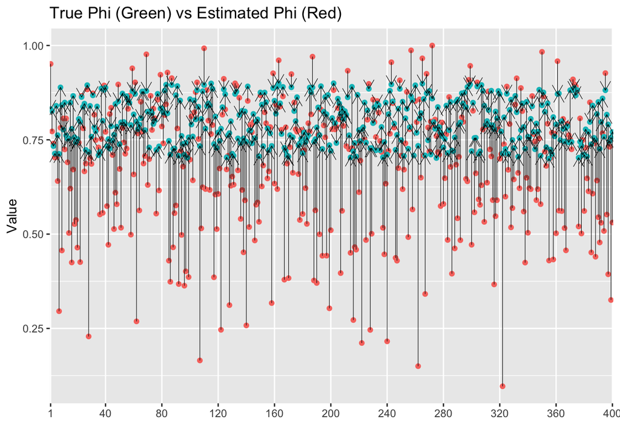

```r
phi.comparison <- melt(cbind(phi.est[,2], phi.true[,2]))
phi.comparison$Var2 <- as.factor(phi.comparison$Var2)
levels(phi.comparison$Var2) <- c("phi.est", "phi.true")
phi.comparison <- data.frame(phi.comparison)
phi.comparison$Var1 <- as.factor(phi.comparison$Var1)

ggplot(data=phi.comparison, aes(x=Var1, y=value), position=position_dodge(0.5)) +
  labs(title = "True Phi (Green) vs Estimated Phi (Red)") +
  xlab("") +
  ylab("Value") +
  labs(color="Phi") +
  geom_point(aes(colour=Var2)) +
  geom_line(arrow = arrow(length=unit(0.30, "cm")), size = 0.2) +
  scale_x_discrete(breaks = c("1","40","80","120","160","200","240","280","320","360","400")) +
  theme(legend.position="none")
```

Phi MSE:

```r
# compute Mean Squared Error
phi.mse <- (1/K)*sum((phi.true[,2] - phi.est[,2])^2)
phi.mse
```

```
## [1] 0.0364705
```

```r
sig_400.diff.est <- sig.est
```